# extRatum package example

Nikos Patias

12/12/2020

# This notebook provides an example of `extRatum` package

This is a notebook that demonstrates the use of `extRatum` package, using OpenStreetMap data. `extRatum` package can be used to summarise the presence of geospatial features in larger geographic areas. It does so by calculating the area covered by a geospatial feature (i.e. buildings, parks, lakes, etc.). The geospatial features can be of all types of geospatial data (i.e. point, polygons or lines).

In this example, we focus on natural environment characteristics.

We make use of openly available geospatial data to calculate the area covered by water bodies in each National Park in England.

```r
#devtools::install("C:/Users/User/Desktop/extRatum")
library(extRatum)
library(sf)
library(raster)
library(dplyr)
library(tmap)
```

## Read data

First, we read in the boundaries of Great Britain that will help with plotting the results using `raster` package .

```r
GBR <- getData("GADM", country="GBR", level=0)
```

Then, we read in the boundaries of National Parks in England, published by Natural England.

The data downloaded from: https://naturalengland-defra.opendata.arcgis.com/datasets/d333c7529754444894e2d7f5044d1bbf_0.

```r
# read in the national parks boundaries
national_parks <- st_read("lake_data/National_Parks_(England)/National_Parks__England____Natural_England.shp")
```

```r
# plot the boundaries using a static map
tmap_mode("plot")
```

```
## tmap mode set to plotting
```

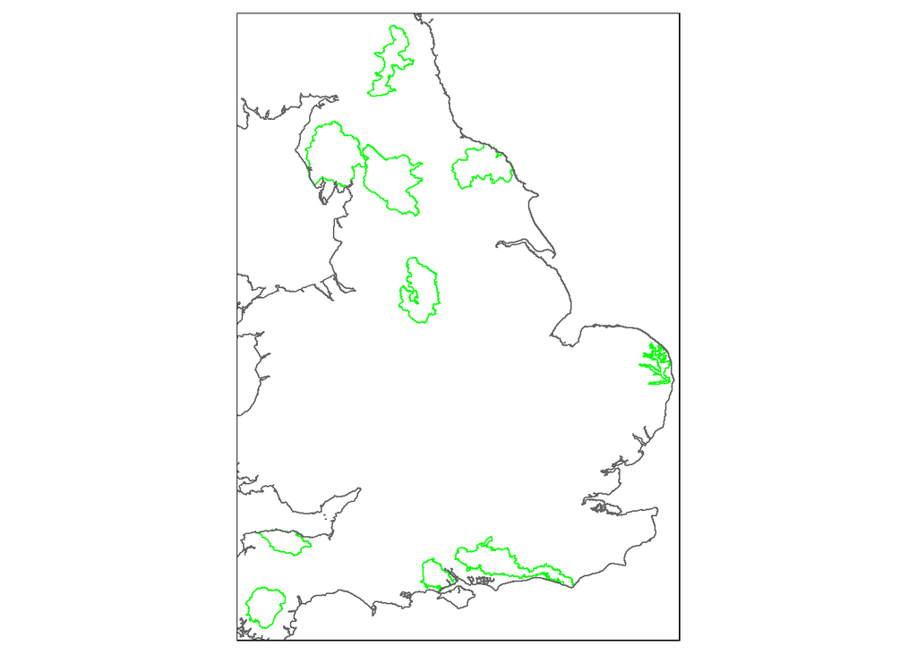

```r
#tmap_mode("view") #use this code for creating an interactive map

tm_shape(national_parks) +
  tm_borders(col = "green") +
  tm_shape(GBR) +
  tm_borders()
```

Finally, we read in the water bodies boundaries in England published by the Environment Agency.

The data downloaded from: https://data.gov.uk/dataset/33dcd836-3813-4233-a3ca-856358312415/wfd-lake-water-bodies-cycle-1

```r
# read in the water bodies boundaries
water_bodies <- st_read("lake_data/EA_WFDLakeWaterBodiesCycle1_SHP_Full/data/WFD_Lake_Water_Bodies_Cycle_1.shp")
```

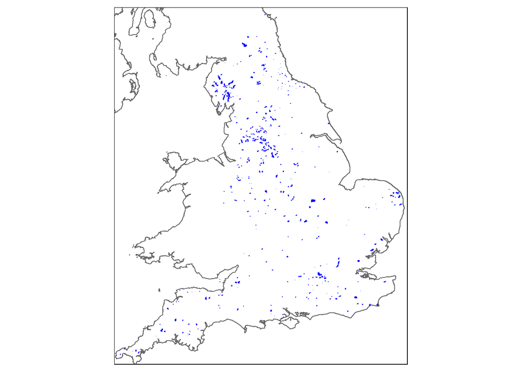

```r
# create a map
tm_shape(water_bodies) +
  tm_borders(col = "blue") +
  tm_shape(GBR) +
  tm_borders()
```

## Run the function

Finally, it is time to run the `areal_calc()` function to calculate the area covered by water bodies in each National Park in England.

Note that we have to pass a planar coordinate system, so the algorithm be able to calculate areas. In this example I use British National Grid.

```r
# run the function from extRatum package
water_coverage <- areal_calc(
  water_bodies,
  national_parks,
  unique_id_code = "FID",
  crs = "epsg:27700"
  )
```

The output of this function will be a dataframe containing:

- the National Park code;
- the total area in sqkm of each National Park;
- the area covered by water bodies in each National Park; and
- the ratio of water bodies area to the total National Park area (or in other words the area covered by water bodies by sqkm).

Given that everything is measured in sqkm, the ratio represents what is the % of area covered by water bodies by sqkm. In this way, we have a relative measure that can be compared across all National Parks and is independent of their size.

```r
head(water_coverage)
```

```
## # A tibble: 6 x 4
##     FID Tot_area_sqkm AreaCovered    Ratio
##   <int>         <dbl>       <dbl>    <dbl>
## 1     1         1653.       0.478 0.000289
## 2     2          693.       1.57  0.00227
## 3     3         2185.       2.86  0.00131
## 4     4         1438.       9.81  0.00682
## 5     5          956.       1.81  0.00190
## 6     6         1441.       0.702 0.000487
```

## Create maps

Finally, I append the data calculated to the original table of National Parks.

```r
# perform a join of tables
national_parks_v2 <- left_join(national_parks, water_coverage, by = "FID")
```

We can now create two maps.

One that shows the total area covered by water bodies.

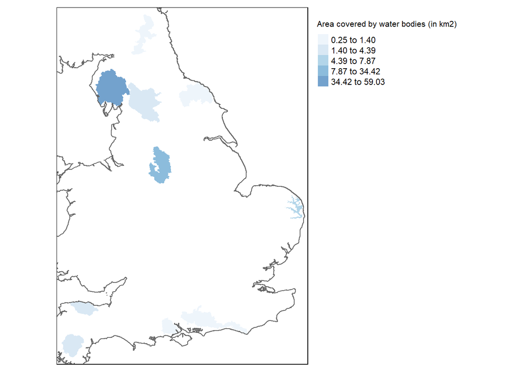

```r
# create a choropleth map
tm_shape(national_parks_v2) +
  tm_fill("AreaCovered",
          style = "fisher",
          palette = "Blues",
          alpha = 0.6,
          id="NAME",
          title="Area covered by water bodies (in km2)")  +
  tm_legend(position = c("right", "top")) +
  tm_layout(legend.outside = TRUE) +
  tm_shape(GBR) +
  tm_borders()
```

And a second, that shows the ratio of water bodies to the total area of each National Park.

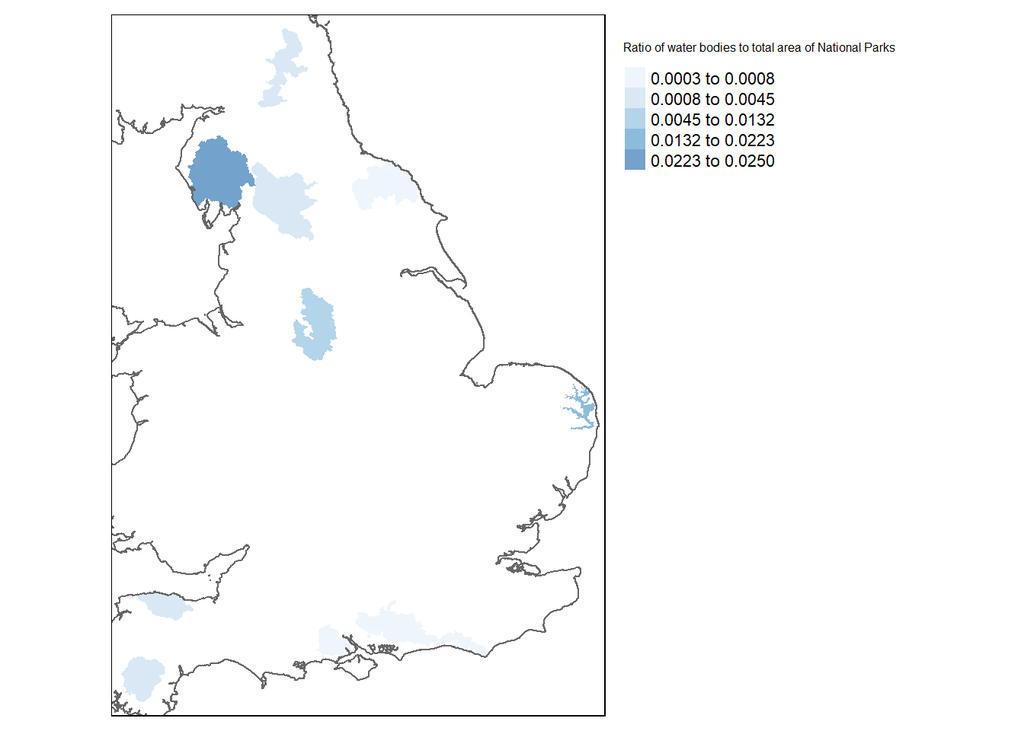

```r
# create a choropleth map
tm_shape(national_parks_v2) +
  tm_fill("Ratio",
          style = "fisher",
          palette = "Blues",
          alpha = 0.6,
          id="NAME",
          title="Ratio of water bodies to total area of National Parks")  +
  tm_legend(position = c("right", "top")) +
  tm_layout(legend.outside = TRUE) +
  tm_shape(GBR) +
  tm_borders()
```